# Venice is drowning (inspection)

# Import dei dati

Cominciamo ad importare i nostri dati e a convertirli in formato time series utilizzando il pacchetto **xts**

```r
data_xts <- read_delim("../data/output/venezia_xts.csv",
                     delim = " ",
                     col_types = cols_only(col_datetime(), col_number()))

venezia_xts <- xts(order.by = data_xts$datetime,
                      x = data_xts$level)

attr(venezia_xts, 'frequency') <- 24
```

# Analisi esplorativa

Procediamo ad esplorare a questo punto la nostra serie storica

Di seguito rappresentiamo la serie storica nella sua interezza e, successivamente, un piccolo estratto:

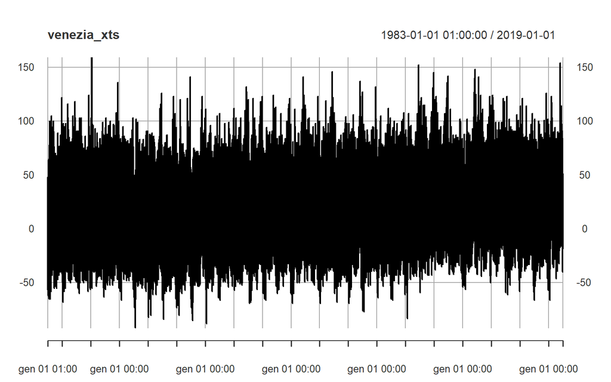

```r
plot(venezia_xts)
```

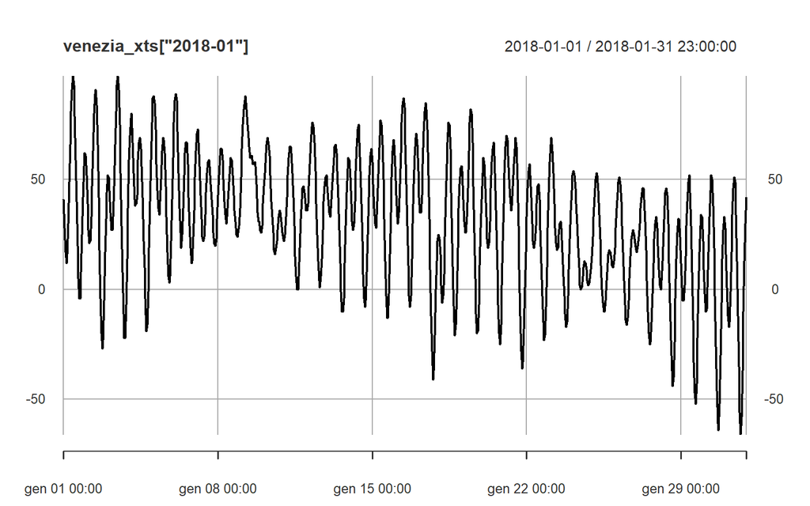

```r
plot(venezia_xts["2018-01"])
```

Effettuiamo un po di manipolazione sulla nostra time series in modo da poter estrapolare alcune visualizzazioni utili alla comprensione del fenomeno

```r
data2 <- as.data.frame(venezia_xts)
data2$datetime <- rownames(data2)
rownames(data2) <- NULL
names(data2) <- c("level", "datetime")
data2$year <- year(data2$datetime)
data2$month <- month(data2$datetime)
data2$day <- day(data2$datetime)
data2$weekday <- factor(wday(data2$datetime), levels=1:7, labels=c("Monday", "Tuesday", "Wednesday", "Thursday", "Friday" , "Saturday", "Sunday"))
data2$hour <- hour(data2$datetime)
data2 <- data2[c("datetime", "year", "month", "day", "weekday", "level")]
```

Eliminiamo l’anno 2019 di cui è disponibile solo la prima osservazione del primo mese

```r
data2 <- data2 %>% filter(year<2019)
```

Ora siamo pronti per visualizzare alcune misure di sintesi

Prima fra tutte visualizziamo la distribuzione del livello delle maree per anno, dal 1983 al 2018

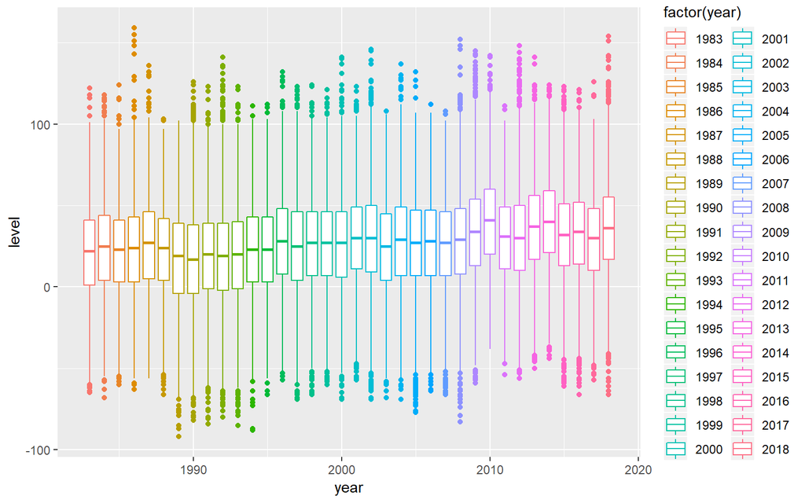

```r
ggplot(data2,
       aes(x = year,
                  y = level,
                  group = year,
                  col = factor(year))) +
  geom_boxplot()
```

In seguito restringiamo il focus per mese

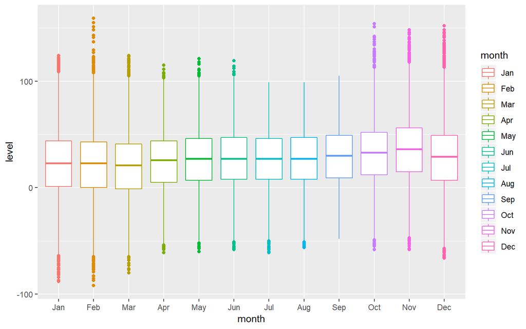

```r
ggplot(data2,
       aes(x = as.factor(month),
           y = level,
           group = month,
           col = as.factor(month))) +
  geom_boxplot() +
  scale_color_discrete("month",
                       labels = month.abb) +
  scale_x_discrete("month",
                   labels = month.abb)
```

Per ultimo visualizziamo la distribuzione per giorno della settimana

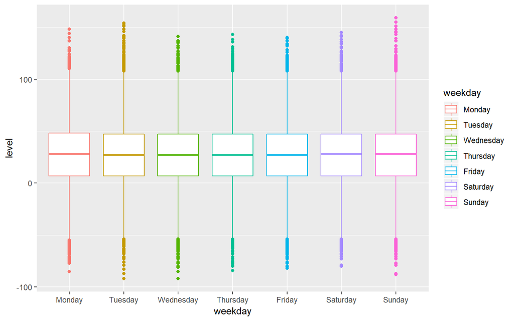

```r
ggplot(data2, aes(x=weekday, y=level, group=weekday, col=weekday)) + geom_boxplot()
```

Per realizzare ulteriori visualizzazioni effettuiamo ancora una serie di manipolazioni per estrarre per ogni anno i valori massimo, minimo e medio del livello delle maree

```r
data_yearly <- data2 %>%
  group_by(year) %>%
  summarise(max = max(level),
            min = min(level),
            mean = mean(level)) %>%
  gather(key, value, -year)
```

Una volta realizzata questa manipolazione possiamo sintetizzarla con una visualizzazione più immediata

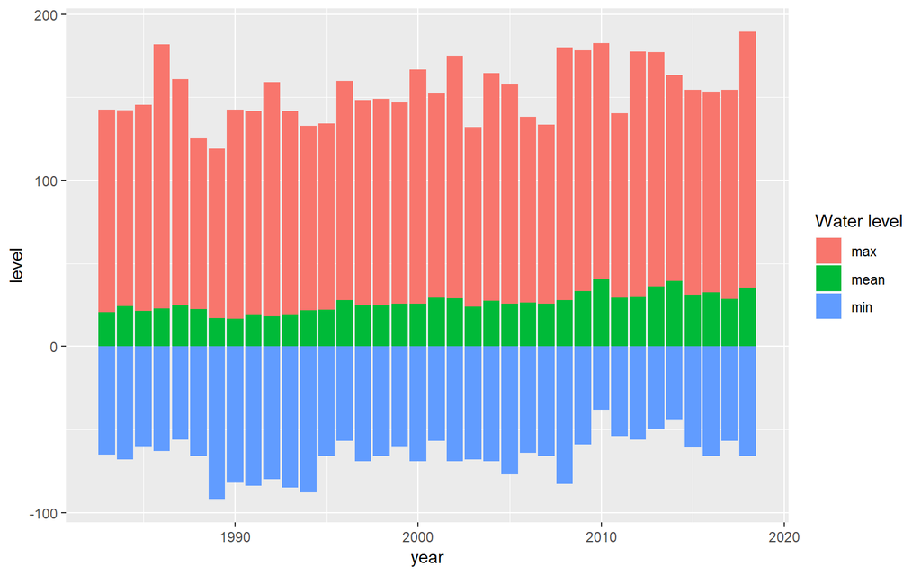

```r
data_yearly %>%
  ggplot(aes(x = year,
             y = value,
             fill = as.factor(key))) +
  geom_bar(stat = "identity") +
  scale_fill_discrete("Water level") +
  scale_y_continuous("level")
```

Per ultima realizziamo una regressione sui nostri punti di massimo, minimo e media distinti per anno. Come è possibile osservare sembrerebbe essere presente una generale tendenza alla crescita per tutti e tre i valori.

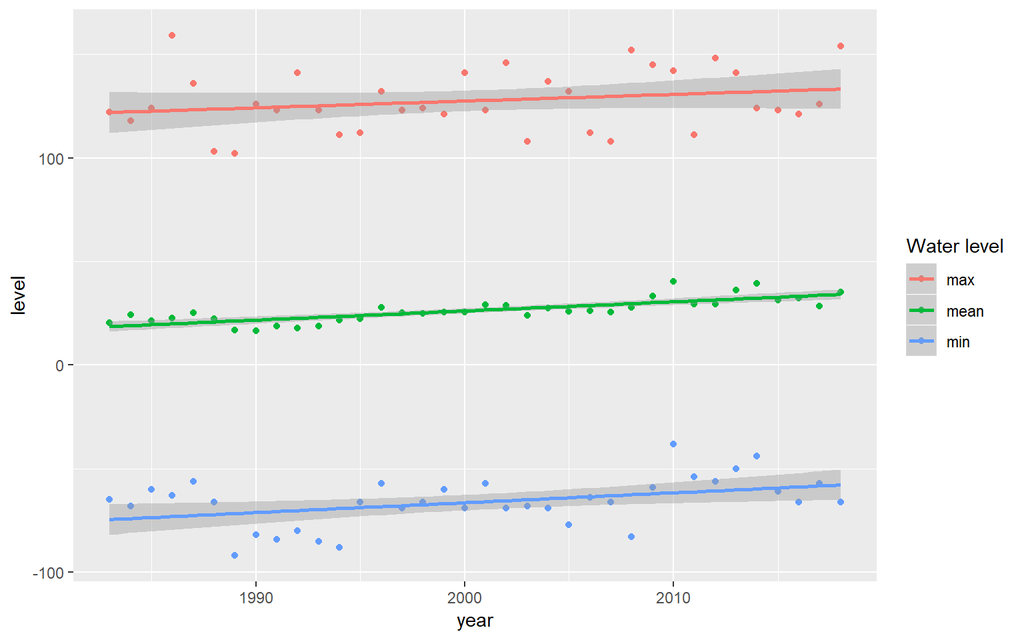

```r
data_yearly %>%
  ggplot(aes(x = year,
             y = value,
             col = as.factor(key))) +
  geom_point() +
  geom_smooth(method = "lm") +
  scale_color_discrete("Water level") +
  scale_y_continuous("level")
```

Dario Bertazioli, Fabrizio D’Intinosante

2019-11-13